# Case-study-hypertension-classification

Hanchao Zhang, M.S.

## Motivation

The pathology of hypertension has been found with several medical studies, salt intaking is one of the most important risk factors for having hypertension. Instead of seeing the association of hypertension and salt intake, we focus on other factors that might have the impact on the odds of having hypertension.

Moreover, our case study also introduced the logistic regression and survey-weighted logistic regression, focusing on the difference of the two models and obviously survey-weighted logistic regression would be our choice of the model since we are using the survey data and it is weighted.

## What is the Data

The National Health and Nutrition Examination Survey (NHANES) is a program of studies designed to assess the health and nutritional status of adults and children in the United States. The survey started in the 1970’s and became a continuous program since 1999. A large portion of the data is publicly available at https://wwwn.cdc.gov/nchs/nhanes/default.aspx. The R package nhanesA (https://cran.r-project.org/web/packages/nhanesA/vignettes/Introducing_nhanesA.html) may make it easier to explore the NHANES data for surveys conducted since 1999. Additionally, the linked mortality data are available for NHANES III and later surveys at this site: https://www.cdc.gov/nchs/data-linkage/mortality-public.htm, which will be useful for exploring questions related to survival outcomes of the survey participants.

The data is downloaded by NYC NHANES (a local version of NHANES), The NYC Health and Nutrition Examination Survey (NYC HANES), modeled on the National Health and Nutrition Examination Survey, is a population-based, cross-sectional study with data collected from a physical examination and laboratory tests, as well as a face-to-face interview and an audio computer-assisted self-interview (ACASI).(cited from http://nychanes.org/data/)

## Data Preprocessing

### Load packages

```r
if(!require("nhanesA")){
  install.packages(c("nhanesA", "tidyverse", "knitr", "sas7bdat", "tableone", 'survey' ))
}
library(tidyverse)
library(knitr)
library(sas7bdat)
library(tableone)
library(knitr)
library(kableExtra)
library(broom)
library(caret)
library(rpart)
library(glmnet)
library(pROC)
library(randomForest)
```

### Read the Data from csv File

```r
directory <- getwd()
directory
```

```
## [1] "/Users/hanchao/GitHub/Case-study/hypertension_classification"
```

```r
dat <- read.sas7bdat(paste0(directory,'/dat.sas7bdat'))
```

### Select the Variables that You’re Interesed In

```r
hypertension_DF <- data.frame(
id = dat$KEY,
age = dat$SPAGE,
race = dat$DMQ_14_1,
gender = dat$GENDER,
born = dat$US_BORN,
diet = dat$DBQ_1,
income = dat$INC20K,
diabetes = dat$DX_DBTS,
bmi = dat$BMI,
hypertension = dat$BPQ_2,
drink = dat$ALQ_1_UNIT,
smoking = dat$SMOKER3CAT,
surveyweight = dat$CAPI_WT
)
```

### Adjust the Data Type

After you get you clean data set, adjusting the type of the covariate is very important, and you should do before doing any analysis in R.

Sometimes people forget to change the type of data, and usually, it will give you a totally wrong result.

For example, in `lm()` and `glm()`, the function will automatically make the factor to categorical data and if you didn’t change the type of the data, you will have the wrong result which identify the categorical variables to continous variables

There are several ways that you can have a glance at your data. Plotting the data is an excellent way to understand your data at first sight.

There are several ways that you can have a glance at your data. What I would recommend you is using the summary and str functions to see the data summary

```r
## check the original data type
str(hypertension_DF)
```

```
## 'data.frame':    1527 obs. of  13 variables:
##  $ id          : Factor w/ 1527 levels "133370A","133370B",..: 1 2 3 4 5 6 7 8 9 10 ...
##  $ age         : num  29 44 38 54 44 39 22 44 65 75 ...
##  $ race        : num  110 110 110 250 180 110 110 100 180 180 ...
##  $ gender      : num  2 1 2 1 2 1 1 2 2 2 ...
##  $ born        : num  1 1 1 1 2 1 1 1 2 2 ...
##  $ diet        : num  4 3 4 3 4 5 3 4 3 4 ...
##  $ income      : num  2 1 2 2 2 NaN NaN NaN 1 1 ...
##  $ diabetes    : num  3 3 3 1 3 3 3 1 1 1 ...
##  $ bmi         : num  24.2 24.9 30.5 28.3 28.1 ...
##  $ hypertension: num  2 2 2 2 2 2 2 2 1 1 ...
##  $ drink       : num  1 3 3 NaN 1 3 1 1 NaN NaN ...
##  $ smoking     : num  2 2 2 3 1 1 1 2 1 1 ...
##  $ surveyweight: num  5334 12711 2028 4277 3965 ...
```

The `str()` function will return you the name of the variables along with their type and some values. It helps you to check the levels and missing values in the categorical data.

```r
## find a charactor of the data for further adjustment
summary(hypertension_DF)
```

```
##        id            age             race           gender
##  133370A:   1   Min.   :20.00   Min.   :100.0   Min.   :1.00
##  133370B:   1   1st Qu.:30.00   1st Qu.:100.0   1st Qu.:1.00
##  133380A:   1   Median :42.00   Median :110.0   Median :2.00
##  133380B:   1   Mean   :44.55   Mean   :136.8   Mean   :1.58
##  133390A:   1   3rd Qu.:57.00   3rd Qu.:180.0   3rd Qu.:2.00
##  133410A:   1   Max.   :97.00   Max.   :250.0   Max.   :2.00
##  (Other):1521                   NA's   :59
##       born           diet          income         diabetes
##  Min.   :1.00   Min.   :1.00   Min.   :1.000   Min.   :1.000
##  1st Qu.:1.00   1st Qu.:2.00   1st Qu.:1.000   1st Qu.:3.000
##  Median :1.00   Median :3.00   Median :2.000   Median :3.000
##  Mean   :1.44   Mean   :2.92   Mean   :2.985   Mean   :2.719
##  3rd Qu.:2.00   3rd Qu.:4.00   3rd Qu.:5.000   3rd Qu.:3.000
##  Max.   :2.00   Max.   :5.00   Max.   :6.000   Max.   :3.000
##  NA's   :8      NA's   :3      NA's   :161     NA's   :281
##       bmi         hypertension       drink          smoking
##  Min.   :12.31   Min.   :1.000   Min.   :1.000   Min.   :1.000
##  1st Qu.:23.33   1st Qu.:1.000   1st Qu.:1.000   1st Qu.:1.000
##  Median :26.52   Median :2.000   Median :1.000   Median :1.000
##  Mean   :27.73   Mean   :1.726   Mean   :1.726   Mean   :1.598
##  3rd Qu.:30.71   3rd Qu.:2.000   3rd Qu.:2.000   3rd Qu.:2.000
##  Max.   :69.17   Max.   :2.000   Max.   :3.000   Max.   :3.000
##  NA's   :38      NA's   :3       NA's   :412     NA's   :3
##   surveyweight
##  Min.   : 1030
##  1st Qu.: 2875
##  Median : 3648
##  Mean   : 4116
##  3rd Qu.: 4989
##  Max.   :15422
##
```

So, the first step, we need to, instead of using the numeric class of it, change it to factors.

We can, of course, change it one by one. However, the reason that we plot the data and look at the summary of it first is that it can give us some information so that we can process the data easier.

```r
factorvars <- NULL
## if the mean value of the data is smaller than 4,
## it means these data is very likely to be categorical data, adjust it to factor.
for (i in 2:length(hypertension_DF)) {
  hypertension_DF[hypertension_DF[,i] == 'NaN',i] <- NA
  if( mean(hypertension_DF[,i], na.rm = T) < 5 ){
    ## For NaN, change it to missing value first
    #hypertension_DF[hypertension_DF[,i] == 'NaN',i] <- NA
    hypertension_DF[,i] <- as.factor(hypertension_DF[,i])
    ## Record the categorical data
    factorvars[i] <- names(hypertension_DF)[i]
  }
}
## check the changed data type
str(hypertension_DF)
```

```
## 'data.frame':    1527 obs. of  13 variables:
##  $ id          : Factor w/ 1527 levels "133370A","133370B",..: 1 2 3 4 5 6 7 8 9 10 ...
##  $ age         : num  29 44 38 54 44 39 22 44 65 75 ...
##  $ race        : num  110 110 110 250 180 110 110 100 180 180 ...
##  $ gender      : Factor w/ 2 levels "1","2": 2 1 2 1 2 1 1 2 2 2 ...
##  $ born        : Factor w/ 2 levels "1","2": 1 1 1 1 2 1 1 1 2 2 ...
##  $ diet        : Factor w/ 5 levels "1","2","3","4",..: 4 3 4 3 4 5 3 4 3 4 ...
##  $ income      : Factor w/ 6 levels "1","2","3","4",..: 2 1 2 2 2 NA NA NA 1 1 ...
##  $ diabetes    : Factor w/ 3 levels "1","2","3": 3 3 3 1 3 3 3 1 1 1 ...
##  $ bmi         : num  24.2 24.9 30.5 28.3 28.1 ...
##  $ hypertension: Factor w/ 2 levels "1","2": 2 2 2 2 2 2 2 2 1 1 ...
##  $ drink       : Factor w/ 3 levels "1","2","3": 1 3 3 NA 1 3 1 1 NA NA ...
##  $ smoking     : Factor w/ 3 levels "1","2","3": 2 2 2 3 1 1 1 2 1 1 ...
##  $ surveyweight: num  5334 12711 2028 4277 3965 ...
```

### Rename the Levels of the Factor

As the str function shows, we now have our categorical variable in position. However, it’s kind of hard for us to tell what the different levels represent in categorical variables. So we can rename the level and make it easier to read and analyze later.

```r
hypertension_DF$race <- as.factor(hypertension_DF$race)
levels(hypertension_DF$race) <- c('White', 'Black/African American', 'Indian (American)/Alaska Native', 'Native Hawaiian/Other Pacific Islander', 'Asian', 'Some Other Race')
levels(hypertension_DF$gender) <- c('Male', 'Female')
levels(hypertension_DF$born) <- c('US-born', 'Other')
levels(hypertension_DF$diet) <- c('Excellent', 'Very good', 'Good', 'Fair', 'Poor')
levels(hypertension_DF$income) <- c('Less than $20,000','$20,000 - $39,999','$40,000 - $59,999','$60,000 - $79,999','$80,000 - $99,999','$100,000 or more')
levels(hypertension_DF$diabetes) <- c('Diabetic dx', 'Diabetic but no dx', 'Not diabetic')
levels(hypertension_DF$hypertension) <- c('Yes', 'No')
levels(hypertension_DF$drink) <- c('Weekly', 'Monthly', 'Yearly')
levels(hypertension_DF$smoking) <- c('Weekly', 'Monthly', 'Yearly')
```

### Check Normality of the Numeric Variables

After changing the dataset, we are now, having a clean dataset. To explore the data more, we need to do some analysis on the data and to check some other features of them.

One thing that we want to do first is to check the normality of your continuous data because we have to decide what test statistics to use. For example, we use the t-test to check the difference of the normal distribution and Wilcoxon test to check the difference of non-normal distribution.

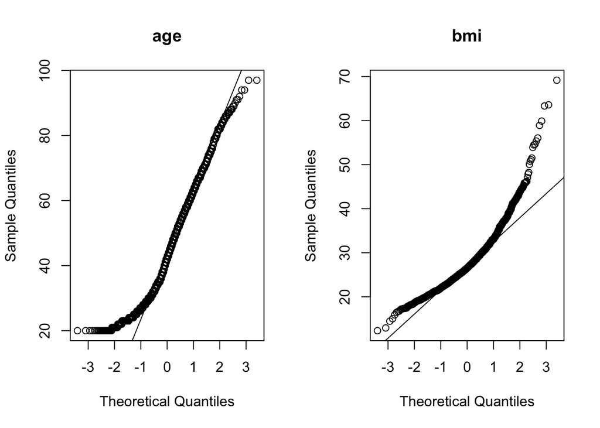

```r
par(mfrow = c(1,2))
for (i in names(hypertension_DF[,-ncol(hypertension_DF)])) {
  if( is.numeric(hypertension_DF[,i] ) ){
    qqnorm(hypertension_DF[,i], main = i)
    qqline(hypertension_DF[,i])
  }
}
```

Since the age and BMI are not normally distributed, we should use the non-parametric(Wilcoxon) method to test the differences.

## Cross-Validation

### K fold Cross-validation

We can perform cross-validation by hard coding. It is pretty simple after understanding the idea of cross-validation.

1. we split the data into k partitions, and we call it k-folds
2. we select one fold as validation dataset, the other k-1 folds as the training dataset
3. fit the model using training dataset
4. estimate the error using the validation dataset
5. repeat with each fold, we can have k validation errors

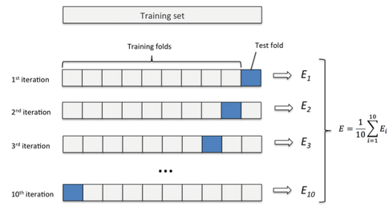

Cross-Validation

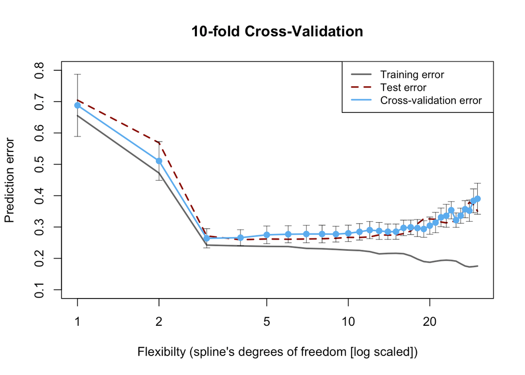

Cross-Validation

We will use the elastic net as our example to do the cross-validation hard coding

as stated before, we can do

- split the data to n fold
- choose the first fold as validation data set
- use the rest of n-1 data sets as training data
- fit the elastic net model in the training dataset
- calculate the validation error on the validation data set
- repeat above steps n times

```r
set.seed(1234)
cv.shrinkage <- function(data = dat.reg, n = "fold", y = "Class", a = 1){
  dd <- data[sample(nrow(data), nrow(data), replace = F),] ## randomnized sorting the data
  dat.splited <- split(dd, rep(1:n, each=nrow(dd)/(n))) ## split the data into n folds
  best.l <- NULL ## NULL vector for best lambda
  fold.error <- NULL ## NULL vector for errors
      for (i in 1:n) {
      train <- dat.splited[-i] ## extract the training from the list
      train <- do.call(rbind, train) ## unlist the training data
      valid <- dat.splited[[i]] ## extract the validation error
      cv.lasso <- cv.glmnet(x = model.matrix(hypertension ~., train), y = as.matrix(train[,y]), nfolds = n, alpha=a, type.measure="deviance", family = "binomial", standardize = T)
      l <- cv.lasso$lambda[which.min(cv.lasso$cvm)]
      fit.lasso <- glmnet(x = model.matrix(hypertension ~., train), y = as.matrix(train[,y]) , family = "binomial", alpha = a, lambda = l)
      pred <- predict(fit.lasso, newx = model.matrix(hypertension ~., valid), y = as.matrix(valid[,y]), type = "response")
      dat.roc <- roc(valid[,y]~pred)
      thres <- coords(dat.roc, "best", ret = "threshold")
      pred[pred <= thres] <- 0
      pred[pred > thres] <- 1
      best.l[i] <- l
      fold.error[i] <- mean(pred != valid[,y])
      }
  data.frame(
    lambda = mean(best.l),
    error = mean(fold.error)
  )
}

dadada <- list()


hypertension_DF$hypertension <- ifelse(hypertension_DF$hypertension == 'No', yes = 0, no = 1)
hypertension_DF <- na.omit(hypertension_DF)


for (i in 1:length(seq(0,1, by = 0.1))) {
  dadada[[i]] <-tryCatch({
    cv.shrinkage(data = hypertension_DF[,-1], n = 10, y = "hypertension", a = seq(0,1, by = 0.1)[i])
  }, error = function(x)NA)
}


tbl.shrinkage <- cbind(
  alpha = (seq(0,1, by = 0.1)),
  do.call(rbind, dadada))

tbl.shrinkage %>%
  xtable::xtable(digits = 4)
```

```r
tbl.shrinkage[which.min(tbl.shrinkage$error),] %>%
  xtable::xtable(digits = 4)
```

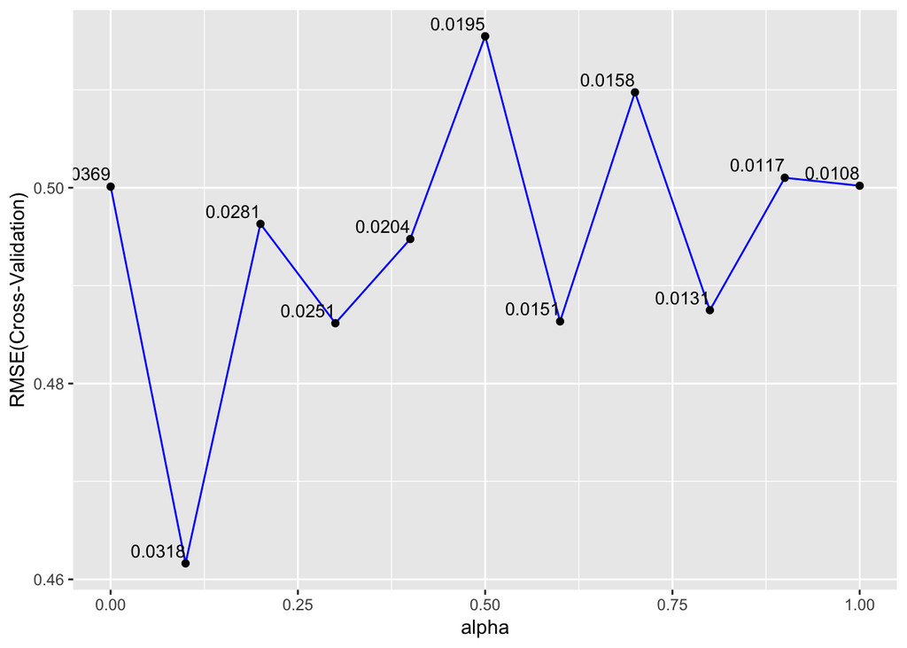

```r
ggplot(tbl.shrinkage) +
  geom_line(aes(x = alpha, y = sqrt(error)), color = 'blue') +
  geom_point(aes(x = alpha, y = sqrt(error), label = lambda)) +
  geom_text(aes(x = alpha, y = sqrt(error),  label = round(tbl.shrinkage$lambda, 4)), size = 3.5, hjust = 1,vjust = -0.5) +
  ylab('RMSE(Cross-Validation)')
```

The x is the alpha, y is the RMSE, and the point with value is the optimal lambda that returns at the alpha.

The alpha equaling to 0.1 and lambda equaling to 0.0318 gives us the least cross-validation error. Thus, the two parameters from elastic net model is $\alpha = 0.1$ and $\lambda = 0.0318$

### `Caret` Package

Luckily, there is a package named `caret` which can help us to do the cross-validation in one line code.

After preprocessing the data, we want to build the best prediction model. We will fit random forest using `caret` package and get our cross-validation error from the `train` function in `caret` package

### Set up a train control for cross-validation using `trainControl()` function from `caret` pacakge.

This is a setting in the later function `train()` where we can train our models and output cross-validation error

```r
train_control<- trainControl(method="cv", number=3)
```

using the `tran()` function with `method = 'glm'`, we get the logistic regression with cross-validation. The output RMSE is the rooted mean square error. We can power it by 2 to get the mean square error.

```r
fit_glm <- train(hypertension~., data=hypertension_DF, trControl=train_control, method="glm")

fit_glm$results$RMSE^2
```

```
## [1] 0.2301481
```

```r
fit_rf <- train(hypertension~., data=hypertension_DF, trControl=train_control, method="rf", tuneLength = 15)
data.frame(
mtry = fit_rf$results$mtry,
mse = fit_rf$results$RMSE^2
) %>%
  arrange(mse) -> rf.mse
rf.mse
```

```
##    mtry       mse
## 1    89 0.1420961
## 2   144 0.1421905
## 3   231 0.1422892
## 4   372 0.1429199
## 5    55 0.1442205
## 6   599 0.1451055
## 7   964 0.1479247
## 8    34 0.1486872
## 9  1550 0.1509841
## 10   21 0.1557200
## 11   13 0.1649133
## 12    8 0.1727987
## 13    5 0.1758880
## 14    3 0.1767806
## 15    2 0.1769732
```

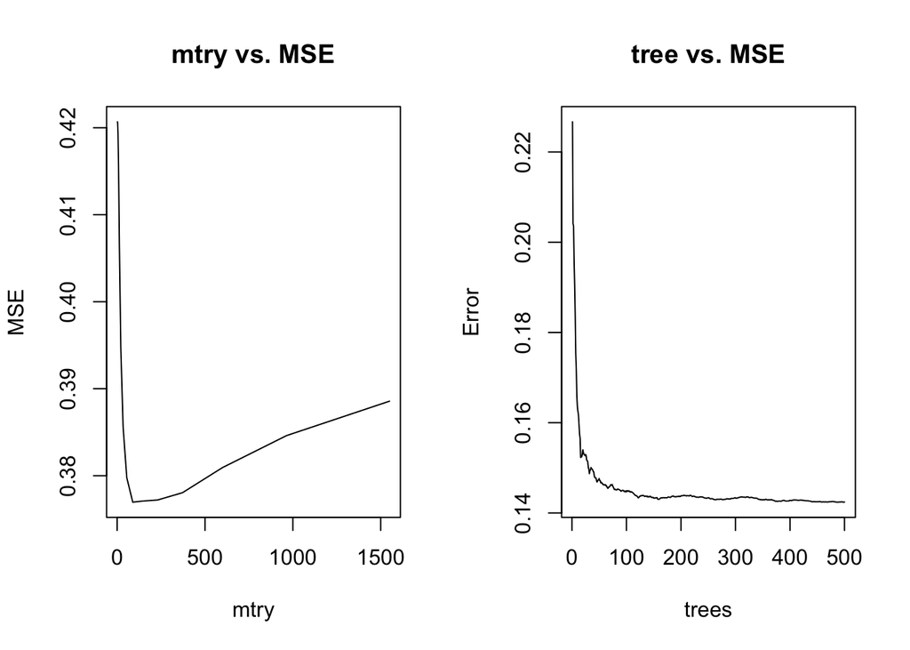

```r
par(mfrow = c(1,2))
plot(fit_rf$results$mtry, fit_rf$results$RMSE, type = 'l', main = 'mtry vs. MSE', xlab = 'mtry', ylab = 'MSE')
plot(fit_rf$finalModel, main = 'tree vs. MSE')
```

Also, you can see the importance plot from the random forest. The importance is evaluated by the variance explained by that variable.

```r
tbl.shrinkage[which.min(tbl.shrinkage$error),]
```

alpha lambda error 2 0.1 0.03182858 0.2131043

```r
rf.mse[1,]
```

mtry mse 1 89 0.1420961

```r
fit_glm$results$RMSE^2
```

[1] 0.2301481

## Final Prediction Model

Now, we can take a look at the random forest model that we fit

```r
fit_rf1 <- randomForest(hypertension~., data = hypertension_DF[,-c(1,13)], mytry = 144, tree = 1000)
fit_rf1
```

```
##
## Call:
##  randomForest(formula = hypertension ~ ., data = hypertension_DF[,      -c(1, 13)], mytry = 144, tree = 1000)
##                Type of random forest: regression
##                      Number of trees: 500
## No. of variables tried at each split: 3
##
##           Mean of squared residuals: 0.1430109
##                     % Var explained: 19.32
```

```r
importance(fit_rf1)
```

```
##          IncNodePurity
## age          33.730018
## race          8.848981
## gender        3.579283
## born          3.104429
## diet          9.642746
## income       12.915448
## diabetes      8.054761
## bmi          29.438754
## drink         6.223414
## smoking       5.567674
```

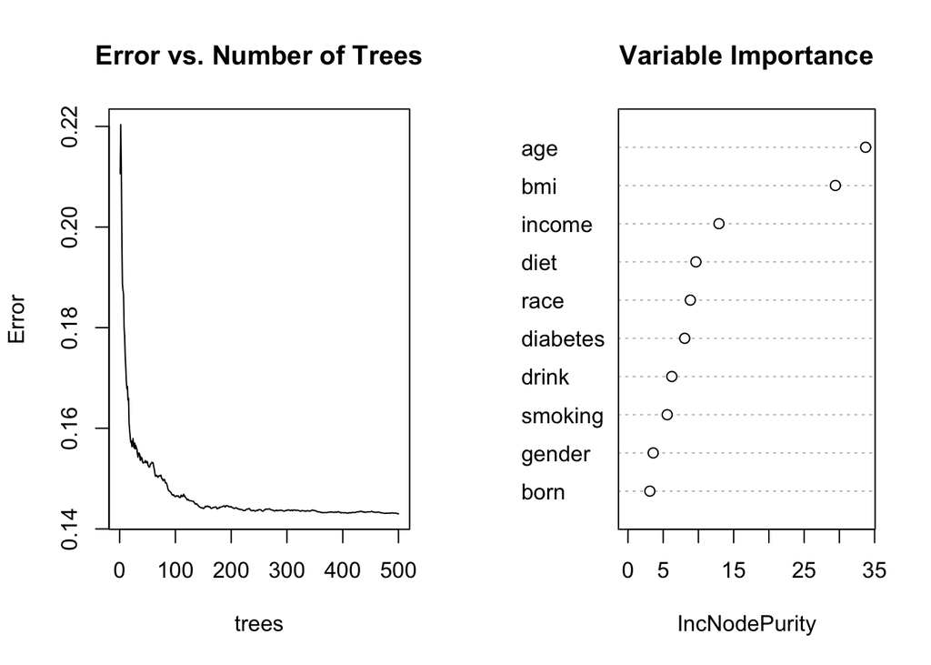

```r
par(mfrow = c(1,2))
plot(fit_rf1, main = 'Error vs. Number of Trees')
varImpPlot(fit_rf1, main = 'Variable Importance')
```

The error does not decrease too much as the number of the tree get to 200. The importance of plot defines the importance of each variable by the reduction of the variance. The age reduces most of the variation following with BMI, income, diet, race, diabetes, drinking status, smoking status, gender, and born place.